# Maps for eastern Canadian marine waters for DFO

Daniel Duplisea

2 November 2022

# What it does

This is essentially a wrapper package to PBSmapping with functions that reflect common features that a DFO scientist would want on a map such as: survey strata, bathymetry data, trawl tracks and various colour options. The maps are functionally useful if not the most beautiful (you will make much more beautiful maps with sf, raster, ggmap or any number of other packages), but they are expressive of the essential information most scientists want in a map. They are usually a lot simpler to make than most of those other packages. It is also quite fast to make the maps and they save well as vector graphics (svg) with small file size and zoomable without pixelation.

It can be useful compared to arcgis, for example, because you can integrate the map easily with your analysis code in R rather than exporting files and making maps in another program. In this way, you can easily create maps to visualise your data even in your initial data explorations. You might then go to another R package, arcgis or grass to make prettier maps if that is what you want but at least this might help you at the start.

Maps are built up. First you call the basic map and then you add features like bathymetry, statistical areas, trawl event data (that you bring yourself). The order in which you do this will affect the final map. For example, survey strata and bathymetry are redundant for certain isobaths so if you plot the strata and then bathymetry, the bathmetric lines will cover the strata lines. Likewise, you will probably want to plot trawl event data as the last step because if you add bathmyetry after the trawl data, the bathymetric lines will likely plot over the top of some of your trawl survey positions.

Finally, you can get more fine grained control and use all the functions in PBSmapping here. PBSmapping is the only dependency so hopefully this will keep people out of dependency hell errors. I verbatim copied functions from the package shape (of course with attribution) to prevent a further dependency.

# What it does not do

This is aimed at producing maps that cover areas of many thousands of square kilometres. If you zoom in on really small areas like bays, you will find the coastline definition to be quite rough but it will still work. If you want to do that and have smoother coastlines, you will need very high resolution basemap data. If you have a shapefile with that data, you can import it using “importShapefile” and then plotMap with that imported shapefile. Depending on how that shapefile describes lat and long, the other functions here may or may not work. You should make your imported shapefile look like “worldLLhigh”, which is the datafile creating the basemap here. You will then find that bathymetry data here is too rough. I would suggest just using PBSmapping directly for such cases as it is built more generally to accommodate your specific data availability. Packages like raster allow you to import maps from google. I am not really trying to hit that market, however, as my mapping needs are modest.

Likewise, this package does not do a lot of GIS stuff but a lot of it is there with the PBSmapping engine behind it. It does not import photos or satellite images and there are no functions in the wrapper package designed to go get data elsewhere.

# Installation

This package is stored on gitlab and is freely available.

```r
if (!require('devtools')) install.packages('devtools') # install devtools if you do not already have it
devtools::install_gitlab("duplisea/ecan.map")
library(ecan.map)
```

# Function conventions

The main functions of the package have suffix “.f”. There are other functions as well but they are called by the .f functions. Most .f functions can be called without arguments to produce a default map or layer. Functions for tracks, arrows, and bubbles require the data that you imported or a data specification so we cannot provide an argumentless implementation: you need to specify your data. We have, however, given examples of how to use them using mock data. Defaults are usually set assuming the Gulf of St. Lawrence is the area of focus. You can modify long and lat coordinates for your situation.

## Building up a map

The basic map with default options is focused on the Gulf of St. Lawrence. This function will be the first step in any map’s construction

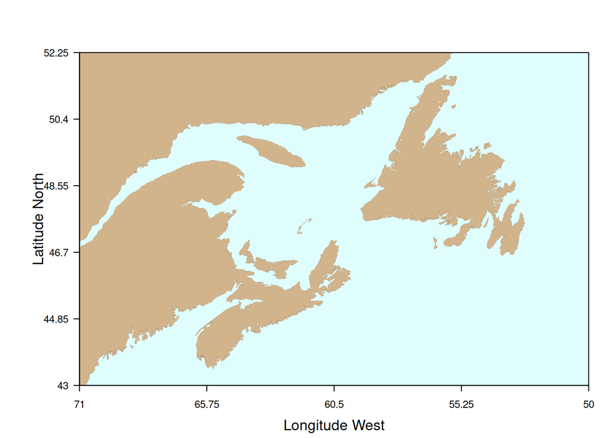

```r
map.f()
```

You can change the colours of the land and sea to your choice. Super ugly pumpkin example:

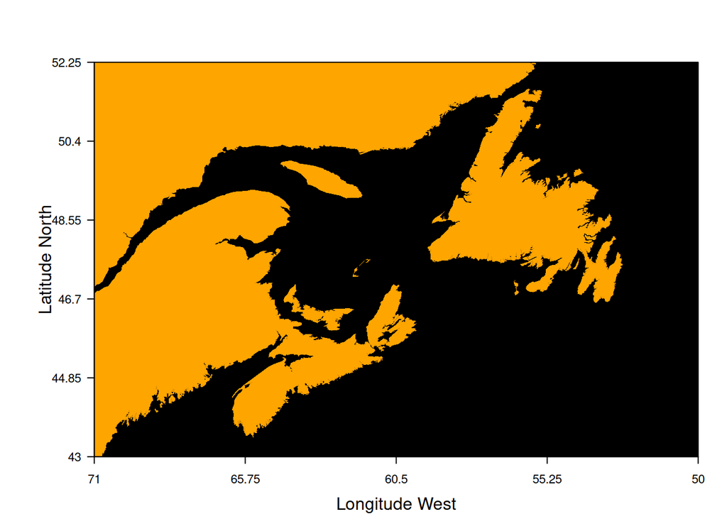

```r
map.f(land.colour="orange",sea.colour="black")
```

### Show bathymetry

The next thing you might want is bathymetry. In this case we choose the 100m and 400m isobaths and we colour the isobath delimeters. We also put the legend for bathmetry in the top left:

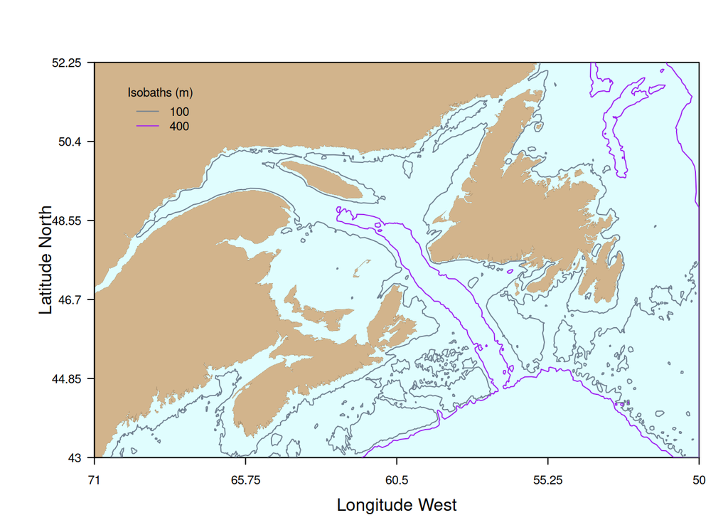

```r
map.f()
bathymetry.f(isobaths=c(100,400), isob.col=c("slategrey","purple"), legend.pos="topleft")
```

### Show particular defined areas

There is a data list in the package that has gathered up definitions of various areas for example, survey strata and NAFO areas, that you may want to show on your map. Presently, only survey strata for some regions are available but the plan is to increase this to include all sorts of areas such as NAFO, fishing areas, MPAs, EBSA …

So for this example let’s put survey strata (added progressively by DFO region) on the map but this time we extend the default map to include eastern Newfoundland shelf. We also do not plot bathymetry because it is too busy and it is largely redundant with the survey strata which are random stratified by depth.

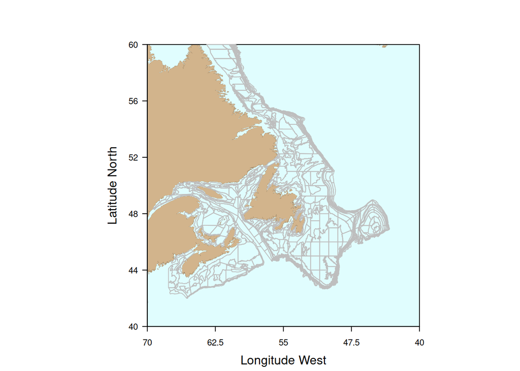

```r
map.f(longs=c(-70,-40), lats= c(40, 60))
stat.area.f("ngsl.trawl.survey.strata")
stat.area.f("sgsl.trawl.survey.strata")
stat.area.f("NL.trawl.survey.strata")
stat.area.f("SS.trawl.survey.strata")
```

You can also highlight particular strata by reference to the PID number for it in the highlight.strata argument

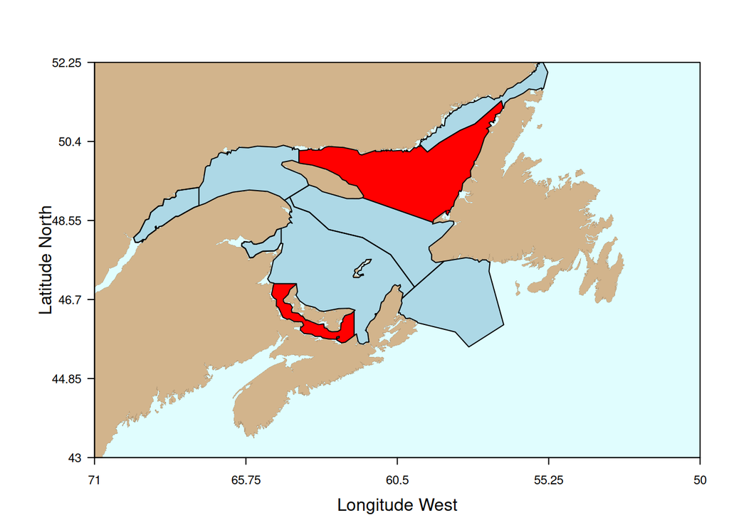

```r
map.f()
stat.area.f("gsl.EAR",strata.colour="lightblue",border.colour="black", highlight.strata=c(2,6), highlight.colour="red")
```

You can also show just your highlighted regions and no others by setting “**show.only.highlight= T**”.

### Clipping and showing Ecosystem Approach Regions (EAR)

There is a polygon set definition of the [ecosystem approach regions (EAR)](https://github/com/duplisea/gslea) developed for the Gulf of St. Lawrence in this package. The EARs were initially defined for large blocks that cover land as well but we want them only for the sea for both plotting and area calculation.

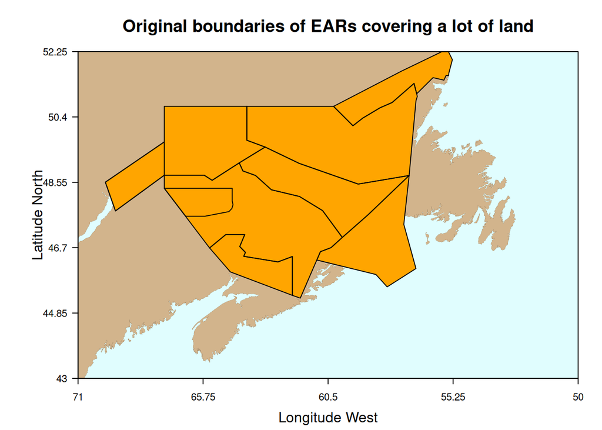

```r
map.f()
# we make the clip at -1500m which is in fact altitude because our file is a bathymetric definition
# and not topographic defintion and therefore altitude is -. Note that you can use this trick to show
# mountains or notable topographic contours on land: use the function bathymetry.f with a negative isobath.
EcoAppRegions.f(min.isobath=-1500, strata.colour="orange", border.colour="black")
title("Original boundaries of EARs covering a lot of land")
```

EARs are generally defined for offshore areas>30 m depth (not all data though) so we should clip the EAR definition by the 30m isobath However, for some EARs like the Northumberland Strait, this eliminates much of the EAR. To the contrary, if we clip it to just the shoreline (0m isobath), the EAR definition then includes places that are not relevant to the EAR like the lagoons in the Magdalen Islands. This is not really a problem if one is interested in surface area of EARs because these areas are small. It is more of a problem clipping to the 0m isobath from a visual presentation point of view because it almost eliminates low lying areas like the Magdalen Islands from your map. You might try then clipping to say 3m.

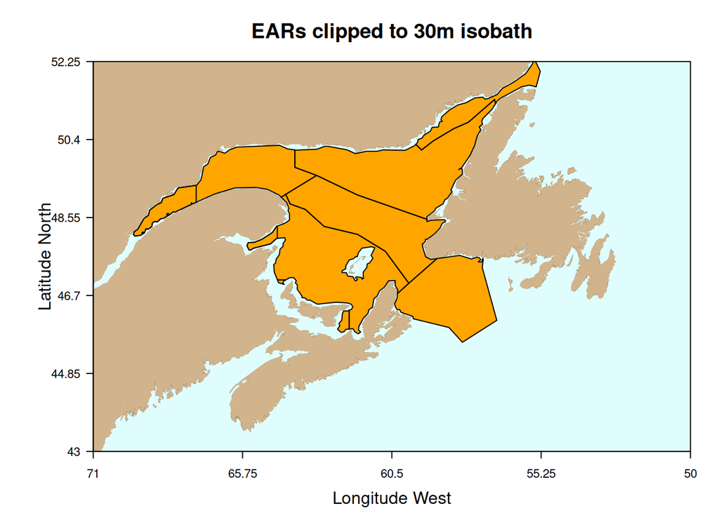

```r
map.f()
EcoAppRegions.f(min.isobath=30, strata.colour="orange", border.colour="black")
title("EARs clipped to 30m isobath")
```

Contrast the map with the 30m clip to one with a 3m clip:

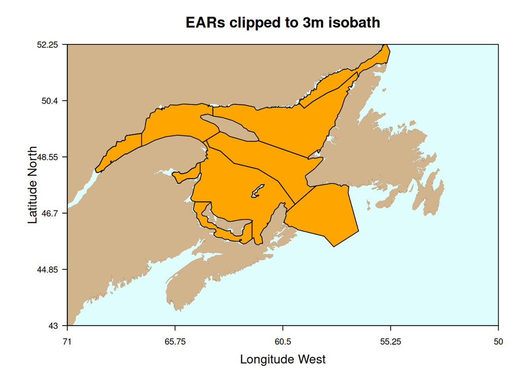

```r
map.f()
EcoAppRegions.f(min.isobath=3, strata.colour="orange", border.colour="black")
title("EARs clipped to 3m isobath")
```

I have probably spent too much space on this because I have included the EAR 3m clip as one of the statistical areas in the list containing them all (type **names(statistical.areas)**). At least the function *EcoAppREgions.f* will show you how to clip polygons to bathymetry for your own boundaries.

### Show events (like survey sets)

You may want to plot all survey positions or fishing positions. The set file for the Northern Gulf summer survey is included here to give you an example of how to plot positions. You first need to convert the long and lat positions to decimal-degrees.

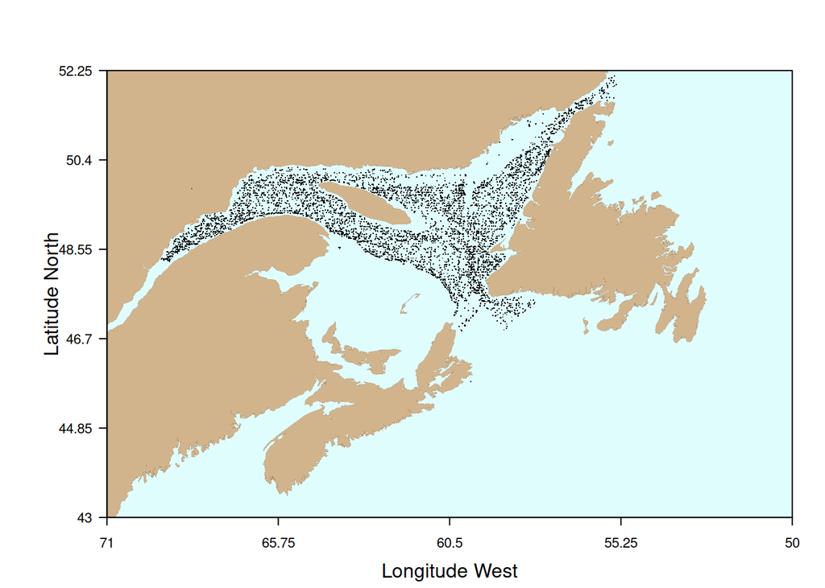

```r
# decimal degrees function specific to how ngulf survey records position, this is not robust code.
# packages like raster and sf will have more robust code to convert decimal degrees. You can also
# convert online at various websites.
decdeg= function(degmin.sec){
  # convert geographic coordinates in degree, minutes, decimal seconds into decimal degrees
  # in one number e.g. 44 degrees, 38 minutes, decimal seconds 73", input as 4438.73
  deg= floor(degmin.sec/10000)
  min= floor((degmin.sec - deg*10000)/100)/60
  decimal.remainder=10*degmin.sec%%1 # modulo 1, %%1, gives you the digits after the decimal
  dd= deg+min+decimal.remainder
  dd
}
x= -decdeg(ngulf.survey.positions$lon_deb*100)
y= decdeg(ngulf.survey.positions$lat_deb*100)

# The basemap and then use points to show all the survey positions for all years of the survey
map.f()
points(x,y,pch=".")
```

It gives you a pretty good idea of areas that are not trawled like the Mecatina Trough in the northeast and east of Anticosti Island (lots of tear-ups in both places).

#### Add events like bubbles (e.g. catch at different locations)

This is functionality directly in PBSmapping so there is not a function wrapper here to do it. We point you to the addBubbles function to do this. It makes bubbles and legends that look nice. It can be a bit iterative to figure out what works best with your data. Event data with a bubble needs one more column (Z) to describe the magnitude of catch or whatever it is you are trying to show. X and Y are the long and lat positions. PBSmapping also requires that you make this an event class object. It essentially means you have an event id (EID) associated with each row. EID is just a sequential numbering from 1 to the end of your file (number of rows).

Here we just randomly sample 20 set positions from the northern gulf survey file, we convert them to decimal degree again (this makes the X and Y columns). We then create the Z column by random draws from a log-normal distribution. Your Z would actually be the biomass per set or abundance per set or whatever it is that you want to show.

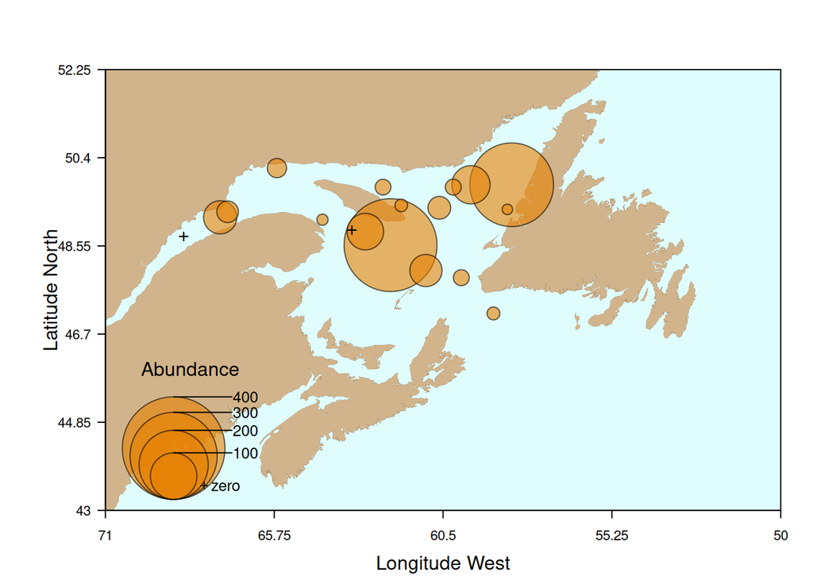

```r
# randomly sample the positions of 20 sets from the ngulf survey set file and convert to decimal degrees
event.positions= sample(1:length(ngulf.survey.positions$lon_deb),20)
x= ngulf.survey.positions$lon_deb[event.positions]
y= ngulf.survey.positions$lat_deb[event.positions]
x= -decdeg(x*100)
y= decdeg(y*100)

# makeup Z values by sampling from a log-nromal distribution and I wanted some zero values
z= rlnorm(20,log(10),log(5))
z[z<3]=0 # make values below 3 equal to 0

# Make it event data. Note that EID is just a vector from 1 to the number of observations.
# Your analysis would likely start here after you imported your data.
your.data= data.frame(EID=1:20, X=x, Y=y, Z=z) # this is what your data.file should look like
fishing.events= as.EventData(your.data)

# plot the base map
map.f()

# show the events using the addBubbles function from PBSmapping
addBubbles(fishing.events,type="perceptual", symbol.bg=rgb(.9,.5,0,.6), legend.type="nested", symbol.zero="+", col="grey")
```

### Show trawl tracks or events with start and end positions

You can add survey tracks and arrows if you have start and end positions of tows. Made up trawl tracks are used here

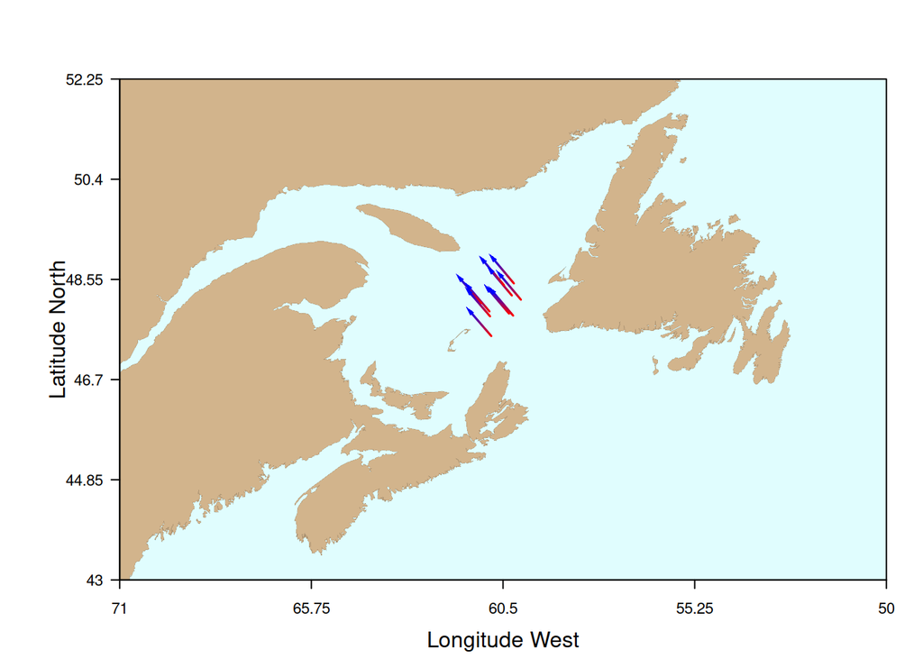

```r
#makeup fake tracks. They are really long tracks just for illustrative purposes
tmp= data.frame(xstart= runif(10,-62,-60),ystart= runif(10,47.5,48.5))
tmp$xend=tmp$xstart*1.01
tmp$yend=tmp$ystart*1.01

# Call the base map
map.f()

# Add the tracks with a colour gradient
tracks.f(tmp$xstart, tmp$ystart, tmp$xend, tmp$yend,start.colour="red", end.colour="blue", number.of.colours=30, lwd=1.5)

# add arrowheads to the tracks
track.arrows.f(tmp$xstart, tmp$ystart, tmp$xend, tmp$yend, arr.lwd=.06, arr.length=0.15, arr.col="blue", col="blue", arr.type="triangle")
```

### All together (unmake this)

Finally a really busy map that you would never use but you can unmake it to the degree you want by dropping off layers. You will likely have a script that stepwise adds things like you see below. Strata are usually the first thing to add because they are polygons that cover everything that came before them. Some place names have been added using text to show you how you can add them.

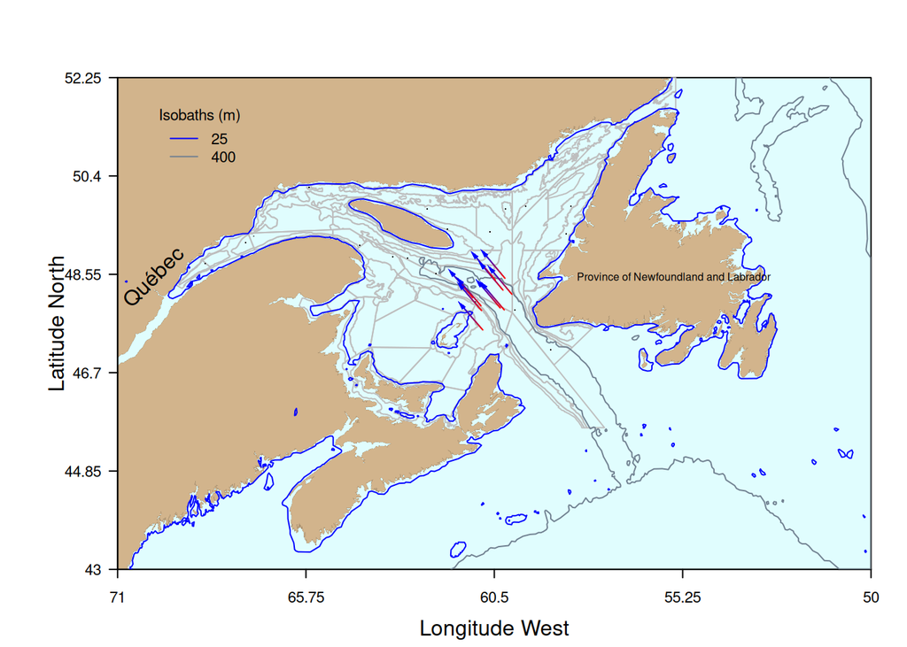

```r
map.f()
stat.area.f("ngsl.trawl.survey.strata")
stat.area.f("sgsl.trawl.survey.strata")
bathymetry.f(isobaths=c(25,400),legend.pos="topleft")
points(x, y, pch=".")
tracks.f(tmp$xstart, tmp$ystart, tmp$xend, tmp$yend,start.colour="red", end.colour="blue", number.of.colours=30)
track.arrows.f(tmp$xstart, tmp$ystart, tmp$xend, tmp$yend, arr.lwd=.06, arr.length=0.15, arr.col="blue",
               col="blue", arr.type="triangle")
text(-55.5,48.5, labels="Province of Newfoundland and Labrador", cex=0.5)
text(-70,48.5, labels="Québec", srt=45)
```

# Additions

Please contribute data for your statistical areas or management areas. Other sorts of functionality or wrappers are also welcome with the provision that they do not create dependencies (i.e. do not call the tidyverse) and which work with simple layering ideas.

# List of functions

Help files are available for these functions

- map.f
- stat.area.f
- EcoAppRegions.f
- bathymetry.f
- tracks.f
- track.arrows.f
- hv.distance.f

# Note

If you are saving graphics files as vector graphics (svg), vector graphics do not do well with colour gradients (files get big) because they have to define a polygon for each colour block in the image. If you have trawl tracks with a colour gradient and many tracks, you should reduce the number of gradients (possibly to 1, i.e. only 1 colour) and this should reduce your file size. If you save them to a raster format (e.g. png), the basic file size will be larger than the svg with one colour but it will not get larger with many gradient colours since a pixel is a pixel be it green or red. That is why photographs are rarely written as vector graphics but they are great for most scientific graphs. Submitting papers to journals with vector graphics means that they do not keep coming back to you looking for raster graphics at high resolution and it makes your submitted manuscript package small.